# PS270 Final Project

## Final Report

Introduction:

For my research, I aim to mainly investigate the relationship between higher education and voter turnout. My hypothesis is: How does achieving a higher education influence voter turnout in elections? This hypothesis is based on the theory that individuals with college degrees or higher tend to have greater awareness of elections compared to individuals with lower education experience, leading to increased voter turnout. This is essential because it will help us understand just how much education level affects voter turnout over time.

Data Section:

This research draws on data from a 2024 statistic published by the Statista Research Department, which reports citizens’ voting rates during U.S. presidential elections from 1964 to 2016, categorized by education level. The voting rates (outcome) serve as the dependent variable, while education level is categorized as the independent variable. Voting rates are measured as the percentage of eligible voters who participated in the election, and education levels are classified into categories ranging from Grade 9–11 to Bachelor’s Degree or higher.

This research employs a cross-sectional design, focusing on voter turnout and education levels within a specific time frame. It does not track individual changes over time but examines how different education levels correlate with voter turnout across the years.

The plot below summarizes the dependent variable (voter turnout) by displaying the average percentage of voter turnout across all education levels for each year from 1964 to 2016. This visualization highlights the trends in overall voter turnout rates during the studied period.

Plot:

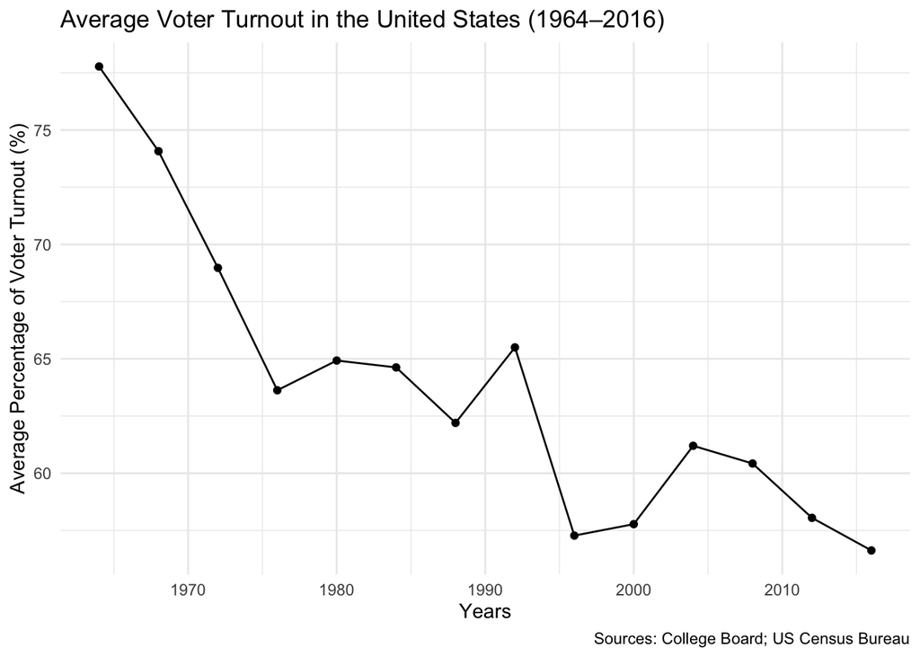

```r
turnout_summary <- turnout |>
  group_by(Year) |>
  summarize(Average_Percentage = mean(Outcome, na.rm = TRUE))

ggplot(turnout_summary, aes(x = Year, y = Average_Percentage)) +
  geom_line() +
  geom_point() +
  labs(
    title = "Average Voter Turnout in the United States (1964–2016)",
    x = "Years",
    y = "Average Percentage of Voter Turnout (%)",
    caption = "Sources: College Board; US Census Bureau"
  ) +
  theme_minimal()
```

Result Section:

```r
turnout_model <- lm(Outcome ~ Education, data = turnout)
turnout_model
```

```
##
## Call:
## lm(formula = Outcome ~ Education, data = turnout)
##
## Coefficients:
##                               (Intercept)
##                                     80.95
##                    EducationGrade 9 to 11
##                                    -35.49
##              EducationHigh School Diploma
##                                    -21.61
## EducationSome college or Associate degree
##                                    -11.54
```

```r
summary(turnout_model)
```

```
##
## Call:
## lm(formula = Outcome ~ Education, data = turnout)
##
## Residuals:
##      Min       1Q   Median       3Q      Max
## -10.0643  -4.7893  -0.8571   1.9607  19.9357
##
## Coefficients:
##                                           Estimate Std. Error t value Pr(>|t|)
## (Intercept)                                 80.950      1.803  44.898  < 2e-16
## EducationGrade 9 to 11                     -35.486      2.550 -13.917  < 2e-16
## EducationHigh School Diploma               -21.614      2.550  -8.477 2.26e-11
## EducationSome college or Associate degree  -11.543      2.550  -4.527 3.52e-05
##
## (Intercept)                               ***
## EducationGrade 9 to 11                    ***
## EducationHigh School Diploma              ***
## EducationSome college or Associate degree ***
## ---
## Signif. codes:  0 '***' 0.001 '**' 0.01 '*' 0.05 '.' 0.1 ' ' 1
##
## Residual standard error: 6.746 on 52 degrees of freedom
## Multiple R-squared:  0.8013, Adjusted R-squared:  0.7898
## F-statistic:  69.9 on 3 and 52 DF,  p-value: < 2.2e-16
```

```r
library(broom)
model_results <- tidy(turnout_model)
knitr::kable(model_results,
             digits = 3,
             caption = "Regression of Voter Turnout by Education Level")
```

Regression of Voter Turnout by Education Level

| term | estimate | std.error | statistic | p.value |
| --- | --- | --- | --- | --- |
| (Intercept) | 80.950 | 1.803 | 44.898 | 0 |
| EducationGrade 9 to 11 | -35.486 | 2.550 | -13.917 | 0 |
| EducationHigh School Diploma | -21.614 | 2.550 | -8.477 | 0 |
| EducationSome college or Associate degree | -11.543 | 2.550 | -4.527 | 0 |